# Technically Correct Data Preparation

Technically Correct Data Preparation Saloomeh (Sally) Arshi 2020-02-20

## Pollutant Data Cleaning

This segment of the code is focused on: identifying the rows of missing data introduced as a result of uploading CSV files and removing them, replacing the -999 and 9999 (as provided by the Ontario Ministry of Environment data definition) with NAs.

```r
# Read Files
CO <- read.csv('/Users//SallyA/Documents/Capstone CKME/Data Files/CO.csv')
NO <- read.csv('/Users//SallyA/Documents/Capstone CKME/Data Files/NO.csv')
NO2 <- read.csv('/Users//SallyA/Documents/Capstone CKME/Data Files/NO2.csv')
NOX <- read.csv('/Users//SallyA/Documents/Capstone CKME/Data Files/NOX.csv')
O3 <- read.csv('/Users//SallyA/Documents/Capstone CKME/Data Files/O3.csv')
PM25 <- read.csv('/Users//SallyA/Documents/Capstone CKME/Data Files/PM25.csv')

# It appears that there are 9999.00 and -999.00 and NAs in the data for missing values

# Omitting all NAs that are in rows at the end of the data frames
CO <- na.omit(CO)
NO <- na.omit(NO)
NO2 <- na.omit(NO2)
NOX <- na.omit(NOX)
O3 <- na.omit(O3)
PM25 <- na.omit(PM25)

# Replace all 9999.00s and -999.00s with NA
CO[CO==9999] <- NA
CO[CO==-999] <- NA

NO[NO==9999] <- NA
NO[NO==-999] <- NA

NO2[NO2==9999] <- NA
NO2[NO2==-999] <- NA

NOX[NOX==9999] <- NA
NOX[NOX==-999] <- NA

O3[O3==9999] <- NA
O3[O3==-999] <- NA

PM25[PM25==9999] <- NA
PM25[PM25==-999] <- NA

# Remove the first column from all dataframes as it is no necessary
CO$X = NULL
NO$X = NULL
NO2$X = NULL
NOX$X = NULL
O3$X = NULL
PM25$X = NULL
```

## Check Summary Statistics of Data

```r
summary(CO)
```

```
##          Date           H01              H02              H03
##  2006-04-27:   2   Min.   :0.0000   Min.   :0.0000   Min.   :0.0000
##  2006-01-01:   1   1st Qu.:0.1100   1st Qu.:0.1100   1st Qu.:0.1000
##  2006-01-02:   1   Median :0.1900   Median :0.1900   Median :0.1800
##  2006-01-03:   1   Mean   :0.2078   Mean   :0.2035   Mean   :0.1955
##  2006-01-04:   1   3rd Qu.:0.2800   3rd Qu.:0.2700   3rd Qu.:0.2600
##  2006-01-05:   1   Max.   :1.3700   Max.   :1.2600   Max.   :1.1000
##  (Other)   :1819   NA's   :73       NA's   :132      NA's   :81
##       H04              H05              H06              H07
##  Min.   :0.0000   Min.   :0.0000   Min.   :0.0000   Min.   :0.0000
##  1st Qu.:0.0900   1st Qu.:0.0900   1st Qu.:0.1000   1st Qu.:0.1300
##  Median :0.1800   Median :0.1700   Median :0.1800   Median :0.2100
##  Mean   :0.1878   Mean   :0.1841   Mean   :0.1939   Mean   :0.2239
##  3rd Qu.:0.2600   3rd Qu.:0.2500   3rd Qu.:0.2600   3rd Qu.:0.2900
##  Max.   :1.0700   Max.   :0.9900   Max.   :0.9900   Max.   :1.0900
##  NA's   :82       NA's   :73       NA's   :76       NA's   :74
##       H08              H09              H10              H11
##  Min.   :0.0000   Min.   :0.0000   Min.   :0.0000   Min.   :0.0000
##  1st Qu.:0.1300   1st Qu.:0.1400   1st Qu.:0.1200   1st Qu.:0.1100
##  Median :0.2200   Median :0.2300   Median :0.2100   Median :0.1900
##  Mean   :0.2451   Mean   :0.2485   Mean   :0.2297   Mean   :0.2076
##  3rd Qu.:0.3300   3rd Qu.:0.3300   3rd Qu.:0.3100   3rd Qu.:0.2800
##  Max.   :1.4600   Max.   :1.1000   Max.   :1.1000   Max.   :1.0200
##  NA's   :73       NA's   :76       NA's   :82       NA's   :99
##       H12              H13              H14              H15
##  Min.   :0.0000   Min.   :0.0000   Min.   :0.0000   Min.   :0.0000
##  1st Qu.:0.1000   1st Qu.:0.1000   1st Qu.:0.1000   1st Qu.:0.1000
##  Median :0.1900   Median :0.1800   Median :0.1800   Median :0.1800
##  Mean   :0.1987   Mean   :0.1917   Mean   :0.1894   Mean   :0.1922
##  3rd Qu.:0.2700   3rd Qu.:0.2700   3rd Qu.:0.2600   3rd Qu.:0.2600
##  Max.   :1.0900   Max.   :0.8700   Max.   :0.9500   Max.   :1.0100
##  NA's   :115      NA's   :84       NA's   :74       NA's   :74
##       H16              H17              H18              H19
##  Min.   :0.0000   Min.   :0.0000   Min.   :0.0000   Min.   :0.000
##  1st Qu.:0.1100   1st Qu.:0.1100   1st Qu.:0.1100   1st Qu.:0.120
##  Median :0.1900   Median :0.2000   Median :0.2000   Median :0.200
##  Mean   :0.1974   Mean   :0.2019   Mean   :0.2087   Mean   :0.212
##  3rd Qu.:0.2700   3rd Qu.:0.2800   3rd Qu.:0.2800   3rd Qu.:0.290
##  Max.   :1.0700   Max.   :1.1100   Max.   :0.8900   Max.   :1.050
##  NA's   :74       NA's   :69       NA's   :70       NA's   :69
##       H20              H21              H22              H23
##  Min.   :0.0000   Min.   :0.0000   Min.   :0.0000   Min.   :0.0000
##  1st Qu.:0.1100   1st Qu.:0.1200   1st Qu.:0.1200   1st Qu.:0.1200
##  Median :0.2000   Median :0.2100   Median :0.2100   Median :0.2100
##  Mean   :0.2154   Mean   :0.2228   Mean   :0.2273   Mean   :0.2248
##  3rd Qu.:0.2900   3rd Qu.:0.3000   3rd Qu.:0.3000   3rd Qu.:0.3000
##  Max.   :1.1200   Max.   :1.4400   Max.   :1.5000   Max.   :1.7000
##  NA's   :68       NA's   :69       NA's   :68       NA's   :68
##       H24
##  Min.   :0.0000
##  1st Qu.:0.1100
##  Median :0.2000
##  Mean   :0.2195
##  3rd Qu.:0.2900
##  Max.   :1.3300
##  NA's   :74
```

The rest of summary stats are supressed to reduce the size of the knitr file.

```r
summary(NO)
summary(NO2)
summary(NOX)
summary(O3)
summary(PM25)
```

# Transpose the hourly data

First need to transpose all hourly data into rows in order to be able to build a time series class of data.

```r
# Transposing the hourly data
New_CO <- CO %>%
  pivot_longer(-Date, names_to = "Hour", values_to = "CO")
New_NO <- NO %>%
  pivot_longer(-Date, names_to = "Hour", values_to = "NO")
New_NO2 <- NO2 %>%
  pivot_longer(-Date, names_to = "Hour", values_to = "NO2")
New_NOX <- NOX %>%
  pivot_longer(-Date, names_to = "Hour", values_to = "NOX")
New_O3 <- O3 %>%
  pivot_longer(-Date, names_to = "Hour", values_to = "O3")
New_PM25 <- PM25 %>%
  pivot_longer(-Date, names_to = "Hour", values_to = "PM25")

# Convering Dates back to Date format
New_CO$Date <- as.Date(New_CO$Date)
New_NO$Date <- as.Date(New_NO$Date)
New_NO2$Date <- as.Date(New_NO2$Date)
New_NOX$Date <- as.Date(New_NOX$Date)
New_O3$Date <- as.Date(New_O3$Date)
New_PM25$Date <- as.Date(New_PM25$Date)
```

## Plotting the data

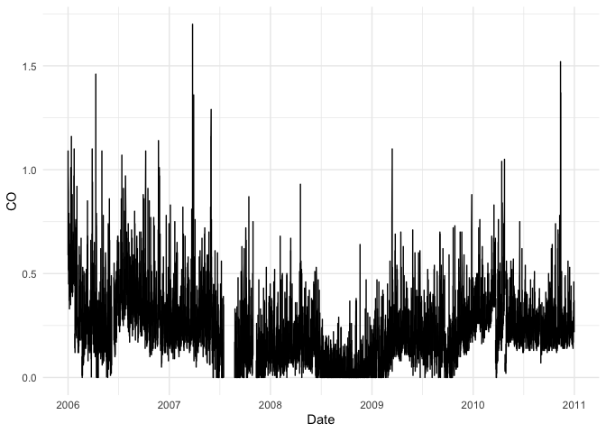

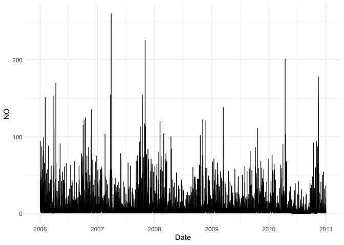

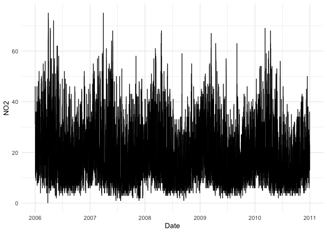

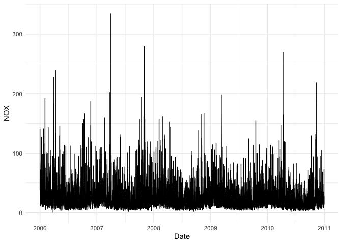

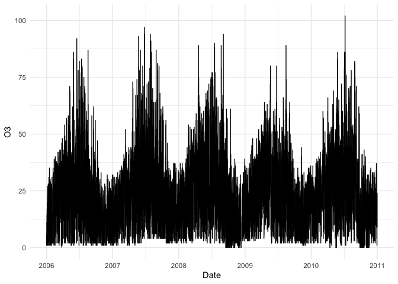

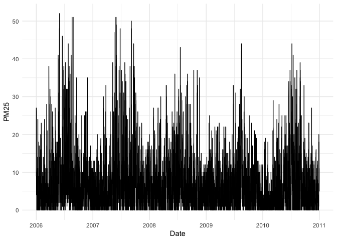

It is clear from these graphs that there are missing data especially in CO dataset where a chunk of data is missing. The missing data needs to be identified and imputed. # NA Statistics To understand what imputation technique would work best. In order to do so, the statNA from ImputeTS package is leveraged to provide a summary statistics on the missing data.

```r
#Statistics on NAs
t_CO <- New_CO$CO
t_NO <- New_NO$NO
t_NO2 <- New_NO2$NO2
t_NOX <- New_NOX$NOX
t_O3 <- New_O3$O3
t_PM25 <- New_PM25$PM25

statsNA(t_CO)
```

```
## [1] "Length of time series:"
## [1] 43824
## [1] "-------------------------"
## [1] "Number of Missing Values:"
## [1] 1897
## [1] "-------------------------"
## [1] "Percentage of Missing Values:"
## [1] "4.33%"
## [1] "-------------------------"
## [1] "Stats for Bins"
## [1] "  Bin 1 (10956 values from 1 to 10956) :      244 NAs (2.23%)"
## [1] "  Bin 2 (10956 values from 10957 to 21912) :      1272 NAs (11.6%)"
## [1] "  Bin 3 (10956 values from 21913 to 32868) :      173 NAs (1.58%)"
## [1] "  Bin 4 (10956 values from 32869 to 43824) :      208 NAs (1.9%)"
## [1] "-------------------------"
```

[output cut: 27 more lines]

```r
statsNA(t_NO)
```

```
## [1] "Length of time series:"
## [1] 43824
## [1] "-------------------------"
## [1] "Number of Missing Values:"
## [1] 206
## [1] "-------------------------"
## [1] "Percentage of Missing Values:"
## [1] "0.47%"
## [1] "-------------------------"
## [1] "Stats for Bins"
## [1] "  Bin 1 (10956 values from 1 to 10956) :      62 NAs (0.566%)"
## [1] "  Bin 2 (10956 values from 10957 to 21912) :      73 NAs (0.666%)"
## [1] "  Bin 3 (10956 values from 21913 to 32868) :      25 NAs (0.228%)"
## [1] "  Bin 4 (10956 values from 32869 to 43824) :      46 NAs (0.42%)"
## [1] "-------------------------"
```

[output cut: 20 more lines]

```r
statsNA(t_NO2)
```

```
## [1] "Length of time series:"
## [1] 43824
## [1] "-------------------------"
## [1] "Number of Missing Values:"
## [1] 200
## [1] "-------------------------"
## [1] "Percentage of Missing Values:"
## [1] "0.456%"
## [1] "-------------------------"
## [1] "Stats for Bins"
## [1] "  Bin 1 (10956 values from 1 to 10956) :      62 NAs (0.566%)"
## [1] "  Bin 2 (10956 values from 10957 to 21912) :      73 NAs (0.666%)"
## [1] "  Bin 3 (10956 values from 21913 to 32868) :      25 NAs (0.228%)"
## [1] "  Bin 4 (10956 values from 32869 to 43824) :      40 NAs (0.365%)"
## [1] "-------------------------"
```

[output cut: 20 more lines]

```r
statsNA(t_NOX)
```

```
## [1] "Length of time series:"
## [1] 43824
## [1] "-------------------------"
## [1] "Number of Missing Values:"
## [1] 200
## [1] "-------------------------"
## [1] "Percentage of Missing Values:"
## [1] "0.456%"
## [1] "-------------------------"
## [1] "Stats for Bins"
## [1] "  Bin 1 (10956 values from 1 to 10956) :      62 NAs (0.566%)"
## [1] "  Bin 2 (10956 values from 10957 to 21912) :      73 NAs (0.666%)"
## [1] "  Bin 3 (10956 values from 21913 to 32868) :      25 NAs (0.228%)"
## [1] "  Bin 4 (10956 values from 32869 to 43824) :      40 NAs (0.365%)"
## [1] "-------------------------"
```

[output cut: 20 more lines]

```r
statsNA(t_O3)
```

```
## [1] "Length of time series:"
## [1] 43824
## [1] "-------------------------"
## [1] "Number of Missing Values:"
## [1] 281
## [1] "-------------------------"
## [1] "Percentage of Missing Values:"
## [1] "0.641%"
## [1] "-------------------------"
## [1] "Stats for Bins"
## [1] "  Bin 1 (10956 values from 1 to 10956) :      47 NAs (0.429%)"
## [1] "  Bin 2 (10956 values from 10957 to 21912) :      37 NAs (0.338%)"
## [1] "  Bin 3 (10956 values from 21913 to 32868) :      150 NAs (1.37%)"
## [1] "  Bin 4 (10956 values from 32869 to 43824) :      47 NAs (0.429%)"
## [1] "-------------------------"
```

[output cut: 20 more lines]

```r
statsNA(t_PM25)
```

```
## [1] "Length of time series:"
## [1] 43824
## [1] "-------------------------"
## [1] "Number of Missing Values:"
## [1] 308
## [1] "-------------------------"
## [1] "Percentage of Missing Values:"
## [1] "0.703%"
## [1] "-------------------------"
## [1] "Stats for Bins"
## [1] "  Bin 1 (10956 values from 1 to 10956) :      68 NAs (0.621%)"
## [1] "  Bin 2 (10956 values from 10957 to 21912) :      56 NAs (0.511%)"
## [1] "  Bin 3 (10956 values from 21913 to 32868) :      59 NAs (0.539%)"
## [1] "  Bin 4 (10956 values from 32869 to 43824) :      125 NAs (1.14%)"
## [1] "-------------------------"
```

[output cut: 19 more lines]

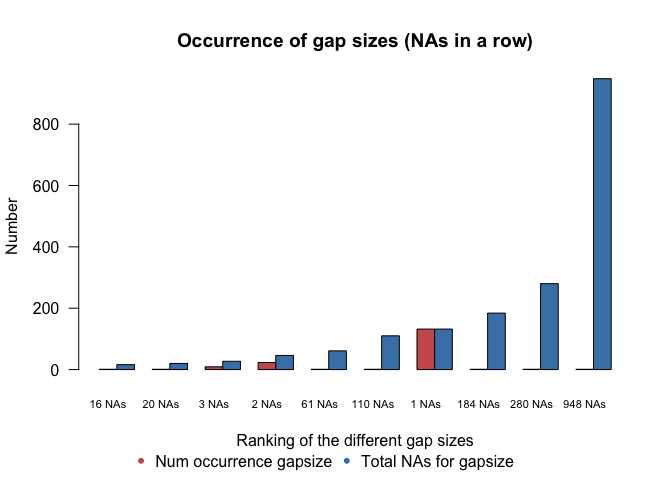

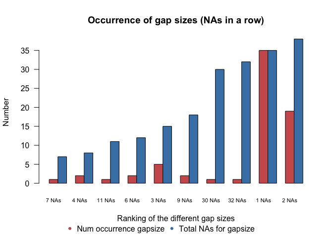

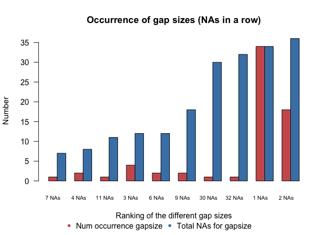

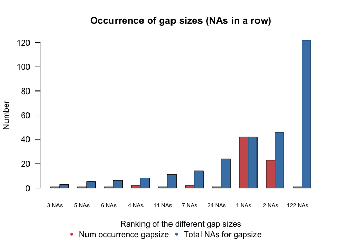

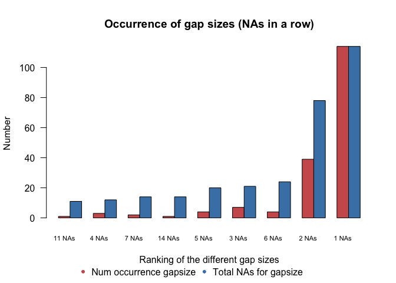

As indicated there are many missing data which needs to be addressed by imputation. Imputation in time series is handled by converting the data to time series and leveraging the ImputeTS package capabilities. For this purpose interpolation is leveraged and of the three different types of interpolations (spline, linear and stine) the linear option is selected. This choice was based on chacking three different options and the summary stats of the dataset after imputation to see which one has the lowest impact on mean and median of the dataset. It was concluded that the linear option would best the best.

```r
#NA Interpolation Impute Linear, Spline, vs Stinterp
intp_CO <- na_interpolation(t_CO, option = "linear")
intp_NO <- na_interpolation(t_NO, option = "linear")
intp_NO2 <- na_interpolation(t_NO2, option = "linear")
intp_NOX <- na_interpolation(t_NOX, option = "linear")
intp_O3 <- na_interpolation(t_O3, option = "linear")
intp_PM25 <- na_interpolation(t_PM25, option = "linear")
```

# Post Imputaiton Plot of Technically Correct Data

Below graphs are the data post imputation. The data is now ready for exploratory data analysis.

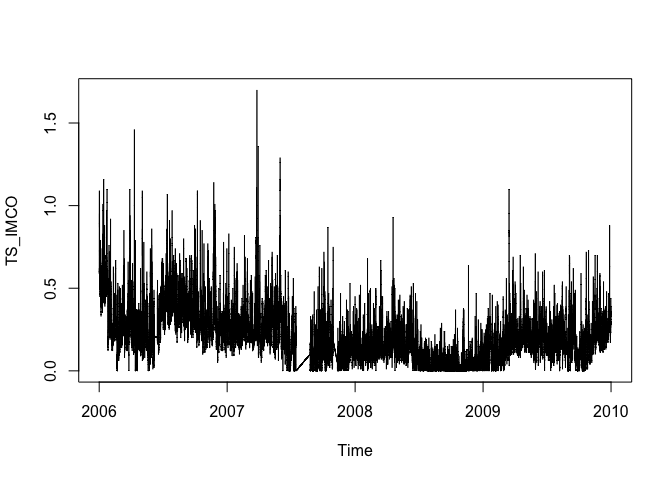

The rest of graphs suppressed due to the size of knitr file.

```r
TS_IMNO <- ts(intp_NO, start = c(2006, 1), end = c(2010, 12), frequency = 24*365)
plot(TS_IMNO)
TS_IMNO2 <- ts(intp_NO2, start = c(2006, 1), end = c(2010, 12), frequency = 24*365)
plot(TS_IMNO2)
TS_IMNOX <- ts(intp_NOX, start = c(2006, 1), end = c(2010, 12), frequency = 24*365)
plot(TS_IMNOX)
TS_IMO3 <- ts(intp_O3, start = c(2006, 1), end = c(2010, 12), frequency = 24*365)
plot(TS_IMO3)
TS_IMPM25 <- ts(intp_PM25, start = c(2006, 1), end = c(2010, 12), frequency = 24*365)
plot(TS_IMPM25)
```